# Medical Appointment No Shows

## By Mahmoud Madkour

- Introduction
- Questions
- Data Wrangling
- Exploratory Data Analysis
- Conclusions

## Introduction

A person makes a doctor appointment, receives all the instructions and no-show.

The most important one if the patient show-up or no-show to the appointment.

We are trying to predict the most important factors that affect the attendance of the patient.

The dataset content 110.527 medical appointments its 14 associated variables.

*Data Dictionary*

1. **Patient_Id:** Identification of a patient.
2. **Appointment_ID:** Identification of each appointment.
3. **Gender:** Male or Female, Female is the greater proportion, woman takes way more care of they health in comparison to man.
4. **DataMarcacaoConsulta:** The day of the actuall appointment, when they have to visit the doctor.
5. **DataAgendamento:** The day someone called or registered the appointment, this is before appointment of course.
6. **Age:** How old is the patient.
7. **Neighbourhood:** Where the appointment takes place.
8. **Scholarship:** True or False.
9. **Hipertension:** True or False.
10. **Diabetes:** True or False.
11. **Alcoholism:** True or False.
12. **Handcap:** True or False.
13. **SMS_received:** 1 or more messages sent to the patient.
14. **No-show:** True or False.

## Questions

*1. Univariate Exploration*

- **Q1:** What is the percentage of patients who show vs. who don't show?
- **Q2:** What percentage of patients are male and female and which one is more booked than the other?
- **Q3:** What is waiting days for Scheduled Day?
- **Q4:** Which the most booking Ages?
- **Q5:** In which Neighborhood are the most appointments taken?
- **Q6:** What percentage of patients are Scholarship, Hipertension, Diabetes, Alcoholism, Handcap and SMS_received?

*2. Bivariate Exploration*

- **Q1:** What is the percentage of male and female patients who are already attending and who do not attend after booking?
- **Q2:** What is the relationship between waiting days and Show the patient?
- **Q3:** What is the most mandatory age to actually attend the booking?
- **Q4:** What is the five most mandatory neighborhood to attend booking already?
- **Q5:** What percentage of patients are Scholarship, Hipertension, Diabetes, Alcoholism, Handcap and SMS_received, And they have already made the booking?

*3. Multivariate Exploration*

- **Q1:** The Distribution of Age For 'Male, Female' and 'Show, Not Show'.
- **Q2:** Patients who received SMS compared to those who received SMS and showed up in 8 most booked neighborhoods.

## Data Wrangling

### Import The Data

### Gathering Data

### Cleaning Data

### What is the structure of your dataset?

After Cleaning We have dataset content 110.521 medical appointments its 14 associated variables.

- 2 Categorical variable(Object).
- 10 Numeric variable (Integer).
- 2 Date Time variable.

### What is/are the main feature(s) of interest in your dataset?

I'm most interested in one if the patient show-up or no-show to the appointment in the dataset.

### What features in the dataset do you think will help support your investigation into your feature(s) of interest?

I think I have advantages in the dataset, which are several specifications for each patient, such as (scholarship, high blood pressure, diabetes, alcohol, hand) as well as appointments (exact day, appointment day).

And This will help me connect the relationships between some of them and find out why not Attending the patient to the doctor

## Exploratory Data Analysis

> **1. Univariate Exploration**

> **2. Bivariate Exploration**

> **3. Multivariate Exploration**

### 1. Univariate Exploration

#### Q1: What is the percentage of patients who Show vs. who don't Show?

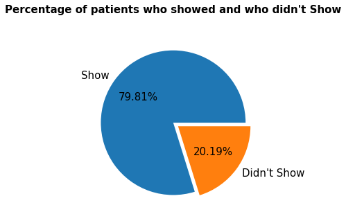

*Answer*

> Percentage of patients who show for their appointments = 79.81%

> Percentage of patients who Don't show for their appointments = 20.19%

#### Q2: What percentage of patients are male and female and which one is more booked than the other?

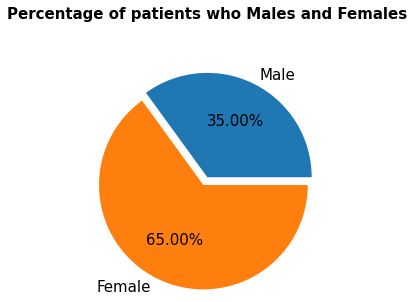

*Answer*

> Proportion of male patients who book appointments = 35.00%

> Proportion of female patients who book appointments = 65.00%

#### Q3: What is waiting days for Scheduled Day?

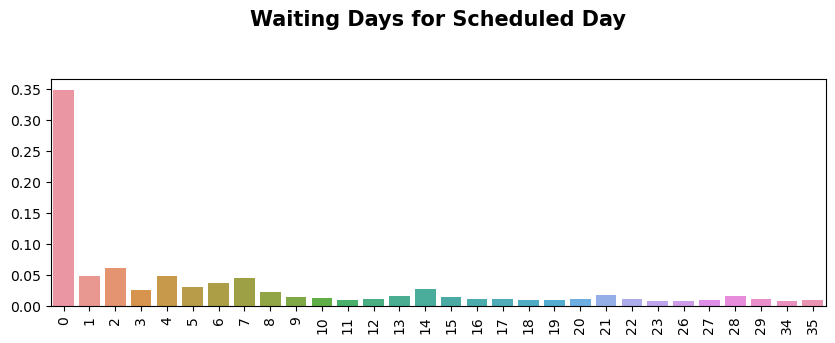

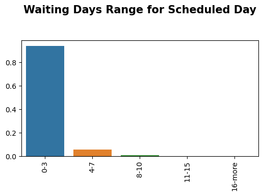

#### Q4: Which the most booking Ages?

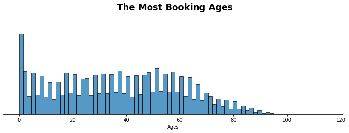

*Answer*

> The average age of patients who book is 37 year.

> 75% of patients who book is 55 year.

#### Q5: In which Neighborhood are the most appointments taken?

*Answer*

> The Most booked neighborhood in `JARDIM CAMBURI` with 7717 booked in this neighborhood.

#### Q6: What percentage of patients are Scholarship, Hipertension, Diabetes, Alcoholism, Handcap and SMS_received?

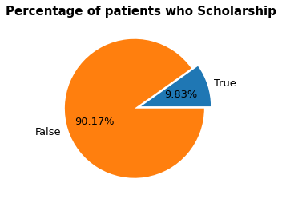

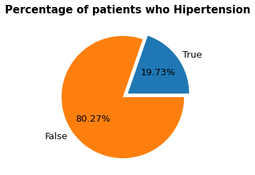

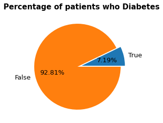

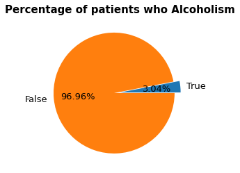

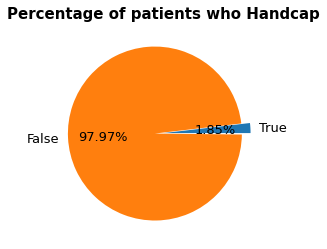

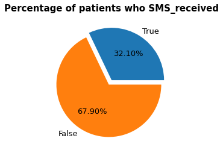

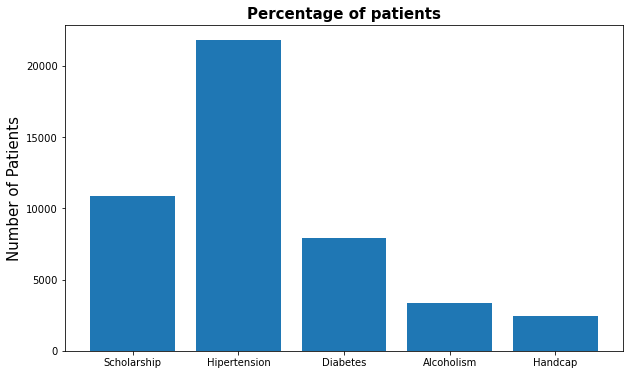

*Answer*

> Percentage of patients who have scholarships = 9.83%

> percentage of patients who Hypertension = 19.73%

> percentage of patients who Diabetes = 7.19%

> percentage of patients who Alcoholism = 3.04%

> percentage of patients who Handcap = 1.85%

> percentage of patients who SMS received = 32.10%

#### Discuss the distribution of variables of interest?

- Show Column

  > The Show column depends on it to connect the relationships with each other.
- Gender Column

  > Females are more numerous than males for reservation.
- Neighborhood Column

  > The most booked neighborhood in `JARDIM CAMBURI` with 7,717 reservations in this neighborhood.
- Scholarship Column

  > The number of patients who booked through the scholarship is about 10%
- Hipertension Column

  > The number of patients who booked with Hypertension is about 20%
- SMS_received Column

  > The number of patients who booked and did not receive letters is about 70%

#### Did you need to perform any transformations?

> In the WaitDays column I needed to convert the values to integer.

#### Did you perform any operations on the data to tidy, adjust, or change the form of the data?

> I added a new column called Waiting Days to calculate the difference between the number of reservation days and the attendance date.

### 2. Bivariate Exploration

#### Q1: What is the percentage of male and female patients who are already attending and who do not attend after booking?

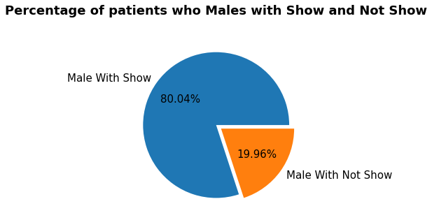

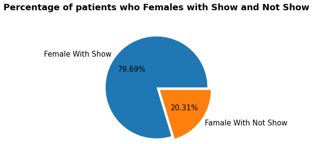

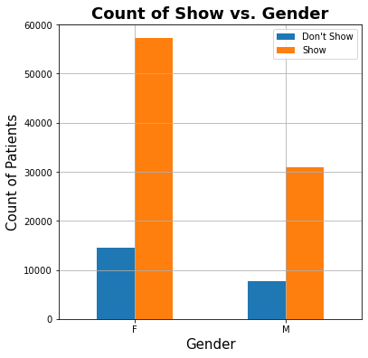

*Answer*

> Proportion of **male** patients who book appointments and actually **attend** their appointments = 80.04%

> Proportion of **male** patients who book appointments and **don't attend** their appointments = 19.96%

> Proportion of **female** patients who book appointments and actually **attend** their appointments = 79.69%

> Proportion of **female** patients who book appointments and **don't attend** their appointments = 20.31%

#### Q2: What is the relationship between waiting days and Show the patient?

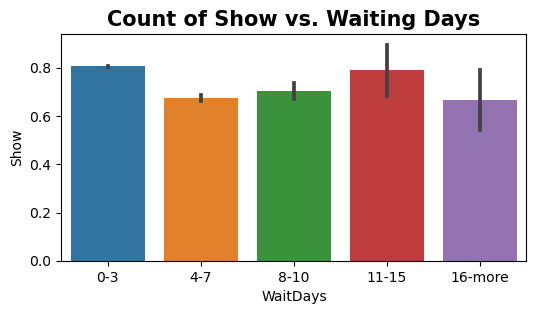

#### Q3: What is the most mandatory age to actually attend the booking?

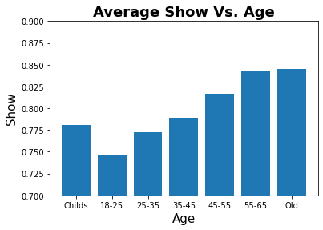

*Answer*

> Older patients and children under the age of 18 keep their appointments more often than younger patients (18-35).

> The older one gets, the more serious the attendance.

#### Q4: What is the five most mandatory neighborhood to attend booking already?

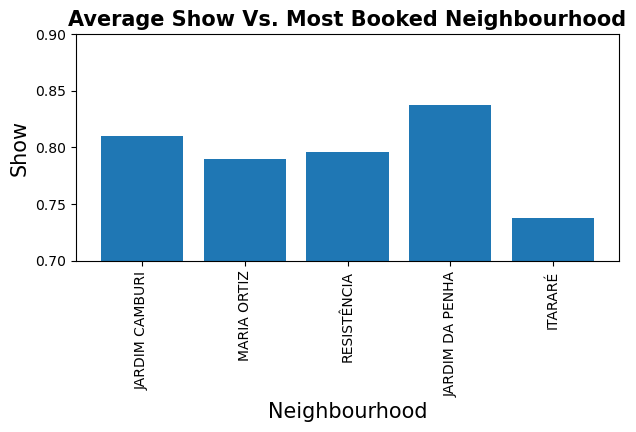

*Answer*

> The most mandatory neighborhood to attend booking already is JARDIM DA PENHA

#### Q5: What percentage of patients are Scholarship, Hipertension, Diabetes, Alcoholism, Handcap and SMS_received, And they have already made the booking?

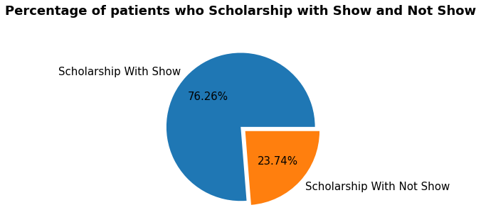

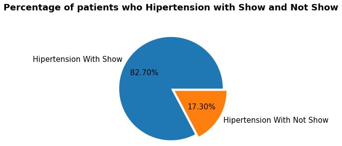

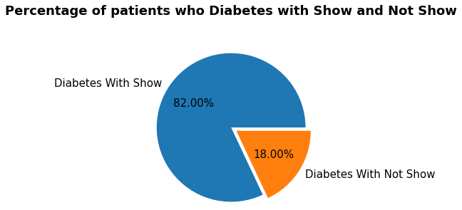

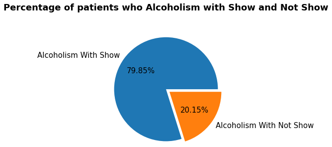

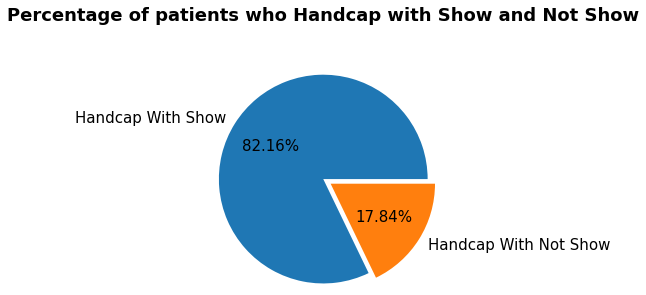

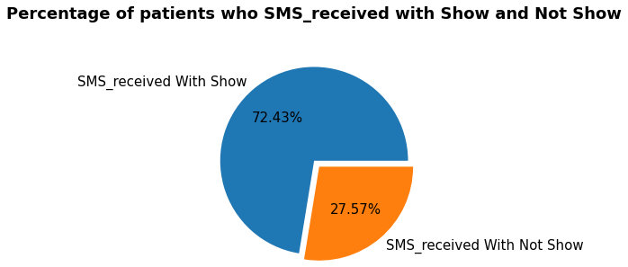

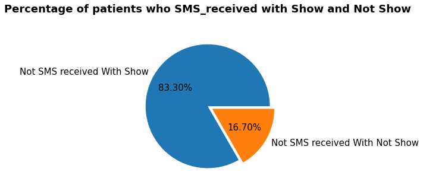

*Answer*

> Percentage of patients who have scholarships, and show the booking = 76.26%

> percentage of patients who Hypertension, and show the booking = 82.70%

> percentage of patients who Diabetes, and show the booking = 82.00%

> percentage of patients who Alcoholism, and show the booking = 79.85%

> percentage of patients who Handcap, and show the booking = 82.16%

> percentage of patients who SMS received, and show the booking = 72.43%

Make me put a constant that we can walk on in the previous ratios of the six variables...

- All percentages less than 80% are considered a problem and affect attendance at the booking date

We find three variables that affect attendance at a booking which are the **Scholarships**, **Alcoholism**, and **SMS received**.

#### Talk about some of the relationships you observed in this part of the investigation...

- Gender vs. Show

  > The most mandatory neighborhood to attend booking already is JARDIM DA PENHA
- Scholarship vs. Show

  > There is an effect on patients who have a scholarship and did not attend.

> Percentage of patients who have a scholarship and did not attend about 25%
- Alcohol vs. Show

  > There is an effect on patients who drink alcohol and do not attend.

> Percentage of patients who drink alcohol and did not attend about 20%
- Received_SMS vs. Show

  > There is an effect on patients who received SMS and did not attend.

> Percentage of patients who received SMS and did not attend about 30%

### 3. Multivariate Exploration

#### Q1: The Distribution of Age For 'Male, Female' and 'Show, Not Show'.

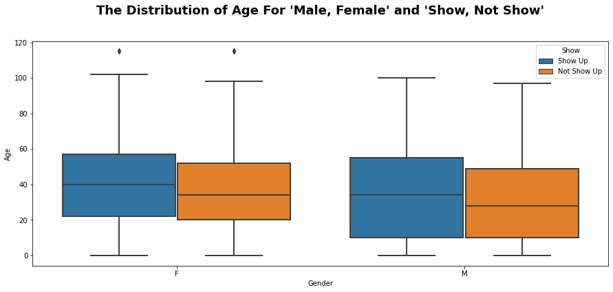

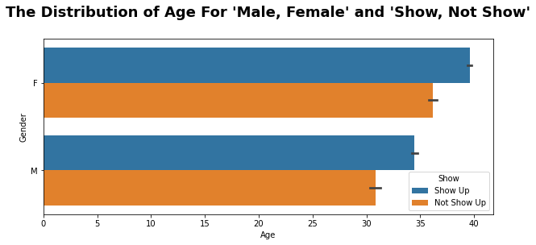

#### Q2: Patients who received SMS compared to those who received SMS and showed up in 8 most booked neighborhoods

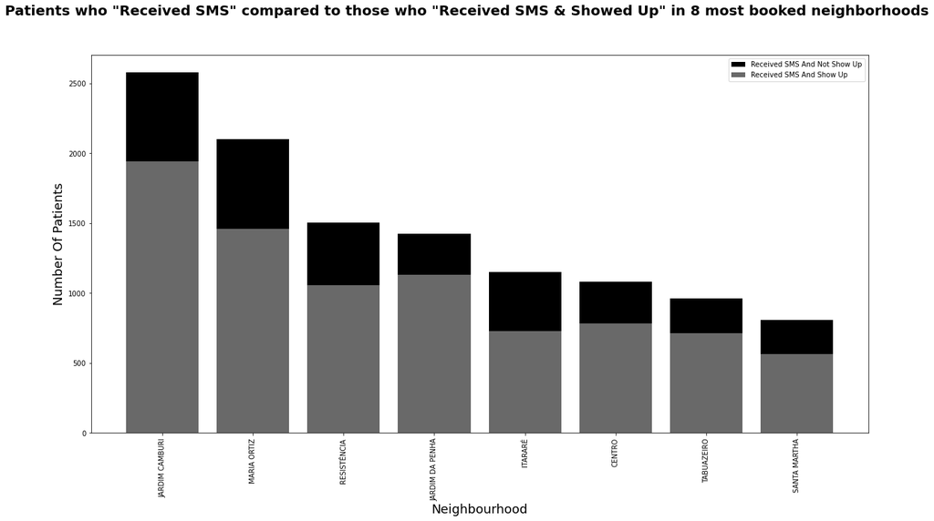

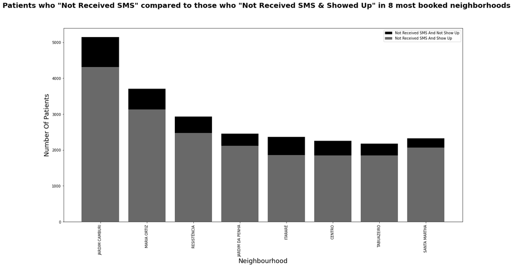

*Answer*

> I expected that patients who do not received SMS are the most not show up.

> But the result is the opposite, because patients who do not received SMS, many of them show up compared to those who received SMS.

## Resources

> https://www.kaggle.com/ahmedmohameddawoud/why-patients-do-not-show-up-for-the-appointment

> https://www.kaggle.com/ayakenawy/medical-no-show-data-analysis-with-steps